# Data wrangling, munging and creating tidy datasets

2019-02-02

## Today's Agenda

- Review data importing, cleaning and munging data
- Creating tidy datasets
- In-class tidy'ing

## Pulse

[interactive chart not shown]

## Data wrangling

Data wrangling or munging is the process of going from raw to useful data. This can be 60-80% of the time spent on a project. *Data Wrangling Cheatsheet* Steps may include any or all of the following:

Step

Examples

Import

- read.table(html,json)

Clean

- filter and subset
- standardize
- renaming
- type conversions

Reformat

- merging
- reshaping
- aggregating

## Data importing – good practices

```r
url <- "http://www2.isye.gatech.edu/~jeffwu/wuhamadabook/data/onewaymuzzle.dat"
chp2_muzzle <- read.table(url, header = T)
# google 'how to get data into R'
library(xlsx)
write.xlsx(x = chp2_muzzle, file = "muzzle_data.xlsx", sheetName = "Muzzle Data",
    col.names = T, row.names = F)
```

If you are getting data from the internet, it is a good idea to protect against:

1. data source being down
2. data source being changed
3. other unknown issues

I generally pull the data down, then save the data to an .Rds file. My project includes:

1. commented code used to pull data down
2. commented code used to save data
3. code to read data into R from the saved file
4. AND often project image files as mid-stream checkpoints

## Data wrangling – summaries

?str, ?summary, group_by and dplyr, should mention doBy package  
Sometimes, a picture really is worth a 1000 words.

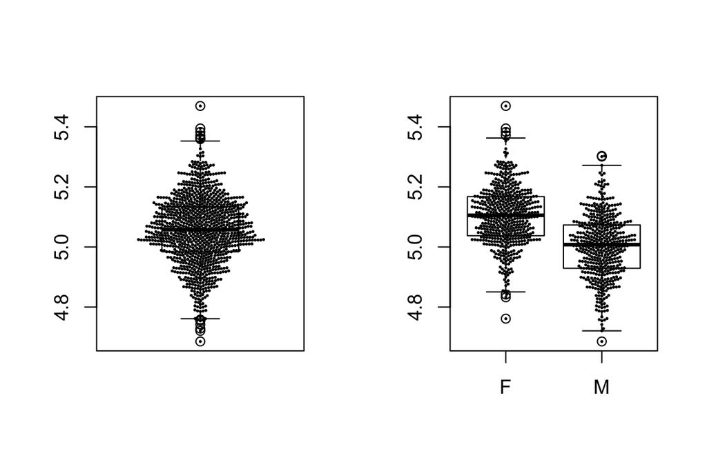

## Problem 1 – Data import

### Part a:

Import data from a girder strength experiment described in Wu and Hamada's Experiment Design book. This data has shear strength data obtained by 10 different methods on 9 different girders. data_file <- "https://www2.isye.gatech.edu/~jeffwu/wuhamadabook/data/fullgirder.dat"

### Part b:

What if the girder names, eg "S1/1", had a meaning such as "steel girder 1 from lot 1" and you wanted to include this in your model. Can you import the data with the name correctly parsed? HINT: ?fread.

## Problem 2 – summary functions

1. what does the imported data look like? Missing values, odd structures?
2. What summaries, text or plots, might you make on the girder data as imported assuming 9 different girders?

## Problem 3 – dplyr

1. Using dplyr functions, can you summarize the data? Mean by method, mean by girder? Min? Max?

## Data wrangling - reformatting/standardizing

Now that we have the data in R, we need to get it into a useable format. One idea for a set of standards for structuring a data set is to create a so called "tidy" data set.

http://vita.had.co.nz/papers/tidy-data.html

Essentially, we need to reformat the data such that:

1. Each variable forms a column.
2. Each observation forms a row.
3. Each type of observational unit forms a table.

Any other structure to the data is considered messy. Sound easy?

## Data wrangling - reformatting

OK, what is wrong with this?

|  | treatmenta | treatmentb |
| --- | --- | --- |
| John Smith | NA | 2 |
| Jane Doe | 16 | 11 |
| Mary Johnson | 3 | 1 |

What we want is something more akin to a model:

\[ y_i = \beta_1 x_{i1} + \beta_2 x_{i2} ... \]

## Data wrangling - base R

```r
    tidy_data1_df<-cbind(messy_data1_df,names=rownames(messy_data1_df))
    tidy_data1_df<-rbind(tidy_data1_df,tidy_data1_df)
    tidy_data1_df[4:6,1]<-tidy_data1_df[4:6,2]
    tidy_data1_df$treatmentb<-rep(c("a","b"),each=3)
    colnames(tidy_data1_df)<-c("value","treatment","names")
    rownames(tidy_data1_df)<-NULL
    tidy_data1_df<-tidy_data1_df[,c(3,2,1)]
    tidy_data1_df$value<-as.numeric(tidy_data1_df$value)
```

## Data wrangling - tidy example

```r
    suppressPackageStartupMessages(library(tidyverse))
    tidy_data1_df<-messy_data1_df %>%
                    tibble::rownames_to_column() %>%
                    gather("treatment","value",treatmenta:treatmentb) %>%
                    mutate(treatment=str_replace(treatment,"treatment","")) %>%
                    mutate(value=as.numeric(value))
    knitr::kable(tidy_data1_df,format = "markdown", caption="Tidy Data")
```

| rowname | treatment | value |
| --- | --- | --- |
| John Smith | a | NA |
| Jane Doe | a | 16 |
| Mary Johnson | a | 3 |
| John Smith | b | 2 |
| Jane Doe | b | 11 |
| Mary Johnson | b | 1 |

https://www.rstudio.com/wp-content/uploads/2015/02/data-wrangling-cheatsheet.pdf

## Data wrangling - messy data symptoms

- Column headers are values, not variable names.
- Multiple variables are stored in one column.
- Variables are stored in both rows and columns.
- Multiple types of observational units are stored in the same table.
- A single observational unit is stored in multiple tables.